# The female rivalry hypothesis - Sensitivity Analyses

Scott Claessens

2020-12-01

```r
library(tidyverse)
library(cowplot)
```

After conducting our main analyses, we fixed the conditions of the agent-based model to those in Experiment 3, and manipulated one parameter at a time to see how sensitive our main result was to model variations. Below, we analyse and visualise five of these parameter sweeps.

# 1. Proportion of promiscuous males

First, we manipulate the proportion of promiscuous males in the population from 0% to 100% in steps of 10%. Load in the data.

```r
d <-
  read.csv('data/v6/cleanData/ovulationSensitivity_MalePromiscuity.csv') %>%
  as_tibble() %>%
  mutate(Run      = factor(Run),
         Sens     = factor(Sens),
         Strategy = factor(Strategy))
```

There are 2200 rows (11 parameters x 100 runs x 2 female strategies).

## 1.1. Analyses

We run mixed ANOVAs to determine (a) the main effect of the proportion of promiscuous males (‘Sens’), (b) the main effect of Strategy, and (c) the interaction between these. Our first ANOVA includes lifetime reproductive success as the dependent variable.

```r
m1.1 <- aov(RS ~ Sens*Strategy + Error(Run/Strategy), data = d)

summary(m1.1)
```

```
##
## Error: Run
##             Df Sum Sq Mean Sq F value Pr(>F)
## Sens        10   3710   371.0    1821 <2e-16 ***
## Residuals 1089    222     0.2
## ---
## Signif. codes:  0 '***' 0.001 '**' 0.01 '*' 0.05 '.' 0.1 ' ' 1
##
## Error: Run:Strategy
##                 Df Sum Sq Mean Sq F value Pr(>F)
## Strategy         1 177.44  177.44  5197.8 <2e-16 ***
## Sens:Strategy   10  49.10    4.91   143.8 <2e-16 ***
## Residuals     1089  37.18    0.03
## ---
## Signif. codes:  0 '***' 0.001 '**' 0.01 '*' 0.05 '.' 0.1 ' ' 1
```

```r
model.tables(m1.1, "means")
```

```
## Tables of means
## Grand mean
##
## 5.686818
##
##  Sens
## Sens
##     0    10    20    30    40    50    60    70    80    90   100
## 7.832 7.302 6.775 6.423 6.064 5.713 5.376 4.995 4.571 4.048 3.458
##
##  Strategy
## Strategy
## Concealers  Revealers
##      5.971      5.403
##
##  Sens:Strategy
##      Strategy
## Sens  Concealers Revealers
##   0   8.286      7.377
##   10  7.759      6.844
##   20  7.210      6.339
##   30  6.827      6.019
##   40  6.434      5.694
##   50  6.030      5.395
##   60  5.619      5.132
##   70  5.203      4.787
##   80  4.700      4.442
##   90  4.125      3.971
##   100 3.485      3.431
```

This analysis shows that, as the proportion of promiscuous males in the population (‘Sens’) increases from 0% to 100%, the fitness advantage of concealed ovulation decreases toward zero.

Let’s run the same model with paternal investment as the dependent variable.

```r
m1.2 <- aov(PI ~ Sens*Strategy + Error(Run/Strategy), data = d)

summary(m1.2)
```

```
##
## Error: Run
##             Df    Sum Sq   Mean Sq F value Pr(>F)
## Sens        10 1.457e+10 1.457e+09    2352 <2e-16 ***
## Residuals 1089 6.745e+08 6.194e+05
## ---
## Signif. codes:  0 '***' 0.001 '**' 0.01 '*' 0.05 '.' 0.1 ' ' 1
##
## Error: Run:Strategy
##                 Df    Sum Sq   Mean Sq F value Pr(>F)
## Strategy         1 792082802 792082802  4817.2 <2e-16 ***
## Sens:Strategy   10 254350745  25435074   154.7 <2e-16 ***
## Residuals     1089 179063124    164429
## ---
## Signif. codes:  0 '***' 0.001 '**' 0.01 '*' 0.05 '.' 0.1 ' ' 1
```

```r
model.tables(m1.2, "means")
```

```
## Tables of means
## Grand mean
##
## 4109.91
##
##  Sens
## Sens
##    0   10   20   30   40   50   60   70   80   90  100
## 8560 7385 6264 5503 4769 4054 3345 2613 1808  906    0
##
##  Strategy
## Strategy
## Concealers  Revealers
##       4710       3510
##
##  Sens:Strategy
##      Strategy
## Sens  Concealers Revealers
##   0   9508       7612
##   10  8369       6401
##   20  7224       5305
##   30  6402       4603
##   40  5566       3972
##   50  4730       3379
##   60  3865       2826
##   70  3059       2168
##   80  2049       1566
##   90  1037        776
##   100    0          0
```

The results for paternal investment are the same.

## 1.2. Visualisation

We now visualise the interaction between proportion of promiscuous males and female strategy with two line graphs, one for each dependent variable. Again, the code for this plot is hidden (see the source .Rmd code for details).

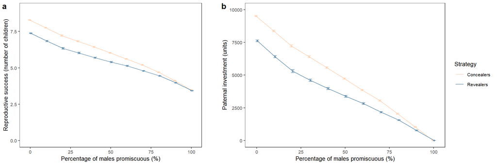

# 2. Decay of aggression damage

Next, we manipulate the decay of aggression damage from 0 (damage is never healed) to 1 (damage heals immediately) in steps of 0.1. Load in the data.

```r
d <-
  read.csv('data/v6/cleanData/ovulationSensitivity_AdDecay.csv') %>%
  as_tibble() %>%
  mutate(Run      = factor(Run),
         Sens     = factor(Sens),
         Strategy = factor(Strategy))
```

There are 2200 rows (11 parameters x 100 runs x 2 female strategies).

## 2.1. Analyses

We run mixed ANOVAs to determine (a) the main effect of the decay of aggression damage (‘Sens’), (b) the main effect of Strategy, and (c) the interaction between these. Our first ANOVA includes lifetime reproductive success as the dependent variable.

```r
m2.1 <- aov(RS ~ Sens*Strategy + Error(Run/Strategy), data = d)

summary(m2.1)
```

```
##
## Error: Run
##             Df Sum Sq Mean Sq F value   Pr(>F)
## Sens        10   22.0  2.2038   6.587 5.78e-10 ***
## Residuals 1089  364.3  0.3345
## ---
## Signif. codes:  0 '***' 0.001 '**' 0.01 '*' 0.05 '.' 0.1 ' ' 1
##
## Error: Run:Strategy
##                 Df Sum Sq Mean Sq F value Pr(>F)
## Strategy         1  65.95   65.95   493.0 <2e-16 ***
## Sens:Strategy   10  84.94    8.49    63.5 <2e-16 ***
## Residuals     1089 145.67    0.13
## ---
## Signif. codes:  0 '***' 0.001 '**' 0.01 '*' 0.05 '.' 0.1 ' ' 1
```

```r
model.tables(m2.1, "means")
```

```
## Tables of means
## Grand mean
##
## 6.762427
##
##  Sens
## Sens
##     0   0.1   0.2   0.3   0.4   0.5   0.6   0.7   0.8   0.9     1
## 6.596 6.810 6.885 6.907 6.856 6.836 6.752 6.747 6.670 6.636 6.690
##
##  Strategy
## Strategy
## Concealers  Revealers
##      6.936      6.589
##
##  Sens:Strategy
##      Strategy
## Sens  Concealers Revealers
##   0   7.247      5.945
##   0.1 7.176      6.445
##   0.2 7.187      6.583
##   0.3 7.115      6.698
##   0.4 7.047      6.666
##   0.5 6.934      6.739
##   0.6 6.850      6.654
##   0.7 6.801      6.694
##   0.8 6.652      6.688
##   0.9 6.654      6.618
##   1   6.628      6.752
```

Let’s run the same model with paternal investment as the dependent variable.

```r
m2.2 <- aov(PI ~ Sens*Strategy + Error(Run/Strategy), data = d)

summary(m2.2)
```

```
##
## Error: Run
##             Df    Sum Sq Mean Sq F value   Pr(>F)
## Sens        10 6.915e+07 6915064   6.421 1.15e-09 ***
## Residuals 1089 1.173e+09 1076904
## ---
## Signif. codes:  0 '***' 0.001 '**' 0.01 '*' 0.05 '.' 0.1 ' ' 1
##
## Error: Run:Strategy
##                 Df    Sum Sq   Mean Sq F value Pr(>F)
## Strategy         1 340290444 340290444  503.79 <2e-16 ***
## Sens:Strategy   10 406455727  40645573   60.17 <2e-16 ***
## Residuals     1089 735576574    675461
## ---
## Signif. codes:  0 '***' 0.001 '**' 0.01 '*' 0.05 '.' 0.1 ' ' 1
```

```r
model.tables(m2.2, "means")
```

```
## Tables of means
## Grand mean
##
## 6229.902
##
##  Sens
## Sens
##    0  0.1  0.2  0.3  0.4  0.5  0.6  0.7  0.8  0.9    1
## 5939 6330 6468 6473 6386 6339 6217 6213 6081 5986 6098
##
##  Strategy
## Strategy
## Concealers  Revealers
##       6623       5837
##
##  Sens:Strategy
##      Strategy
## Sens  Concealers Revealers
##   0   7366       4512
##   0.1 7128       5531
##   0.2 7154       5782
##   0.3 6960       5986
##   0.4 6829       5943
##   0.5 6578       6099
##   0.6 6461       5972
##   0.7 6348       6077
##   0.8 6052       6111
##   0.9 6016       5956
##   1   5963       6233
```

The results for paternal investment are the same.

## 2.2. Visualisation

We now visualise the interaction between the decay of aggression damage and female strategy with two line graphs, one for each dependent variable. Again, the code for this plot is hidden (see the source .Rmd code for details).

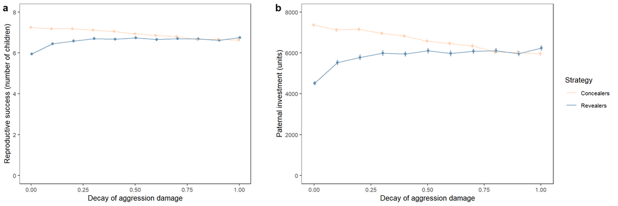

# 3. Cost of aggression to self and other

Next, we systematically vary both (a) the cost of aggression to the perpertrator, and (b) the cost of aggression to the victim. We vary both of these from 0 to 2 in increments of 0.5. Load the data.

```r
d <-
  read.csv('data/v6/cleanData/ovulationSensitivity_costOcostS.csv') %>%
  as_tibble() %>%
  mutate(Run      = factor(Run),
         costO    = factor(costO),
         costS    = factor(costS),
         Strategy = factor(Strategy))
```

This dataset has 5000 rows (5 costs-to-self x 5 costs-to-other x 100 runs x 2 female strategies).

## 3.1. Analyses

We run a three-way mixed ANOVA, including (1) cost to self, (2) cost to other, (3) female strategy, and the interactions between all of these. We first include lifetime reproductive success as the DV.

```r
m3.1 <- aov(RS ~ costO*costS*Strategy + Error(Run/Strategy), data = d)

summary(m3.1)
```

```
##
## Error: Run
##               Df Sum Sq Mean Sq F value   Pr(>F)
## costO          4    8.2    2.04   8.584 7.07e-07 ***
## costS          4  807.1  201.78 849.214  < 2e-16 ***
## costO:costS   16    8.5    0.53   2.241  0.00318 **
## Residuals   2475  588.1    0.24
## ---
## Signif. codes:  0 '***' 0.001 '**' 0.01 '*' 0.05 '.' 0.1 ' ' 1
##
## Error: Run:Strategy
##                        Df Sum Sq Mean Sq F value Pr(>F)
## Strategy                1 192.66  192.66 2944.16 <2e-16 ***
## costO:Strategy          4  59.26   14.81  226.39 <2e-16 ***
## costS:Strategy          4 136.15   34.04  520.14 <2e-16 ***
## costO:costS:Strategy   16  38.92    2.43   37.17 <2e-16 ***
## Residuals            2475 161.96    0.07
## ---
## Signif. codes:  0 '***' 0.001 '**' 0.01 '*' 0.05 '.' 0.1 ' ' 1
```

This three-way interaction is difficult to interpret, but it seems that the effect of condition depends on both the cost of aggression to self AND the cost of aggression to victims. Rather than look at tables of means, we will visualise this effect. But first, let’s see if this result holds for paternal investment.

```r
m3.2 <- aov(PI ~ costO*costS*Strategy + Error(Run/Strategy), data = d)

summary(m3.2)
```

```
##
## Error: Run
##               Df    Sum Sq   Mean Sq F value  Pr(>F)
## costO          4 3.302e+07   8253916   10.11 4.1e-08 ***
## costS          4 2.058e+09 514543594  630.00 < 2e-16 ***
## costO:costS   16 2.862e+07   1788853    2.19 0.00411 **
## Residuals   2475 2.021e+09    816741
## ---
## Signif. codes:  0 '***' 0.001 '**' 0.01 '*' 0.05 '.' 0.1 ' ' 1
##
## Error: Run:Strategy
##                        Df    Sum Sq   Mean Sq F value Pr(>F)
## Strategy                1 916454958 916454958 2913.24 <2e-16 ***
## costO:Strategy          4 278326127  69581532  221.19 <2e-16 ***
## costS:Strategy          4 626976291 156744073  498.26 <2e-16 ***
## costO:costS:Strategy   16 183648327  11478020   36.49 <2e-16 ***
## Residuals            2475 778592620    314583
## ---
## Signif. codes:  0 '***' 0.001 '**' 0.01 '*' 0.05 '.' 0.1 ' ' 1
```

The same pattern emerges, with the three-way interaction reaching significance.

## 3.2. Visualisation

Together, the cost of aggression to self AND other influence the difference between the strategies. To visualise this, we will calculate differences between strategies (in either reproductive success differences, or unit differences, depending on the outcome). We will now create two heatmaps that summarise how the cost of aggression affects the effect of strategy.

```r
d <-
  d %>%
  pivot_wider(id_cols     = c("Run", "costO", "costS"),
              names_from  = Strategy,
              values_from = c("RS", "PI")) %>%
  mutate(DiffRS = RS_Concealers - RS_Revealers,
         DiffPI = PI_Concealers - PI_Revealers)
```

We use `geom_tile` to create our heatmaps. See source code for details.

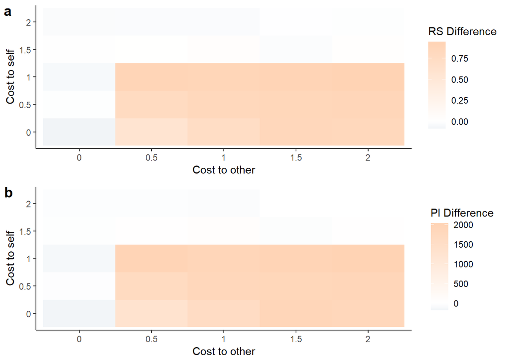

These heatmaps show that the advantage of concealed ovulation only holds when (a) the damage to the victim of aggression is at least 0.5, and (b) the cost to self is less than 1.5. Aggression must be harmful to others, but not too costly for the perpetrator.

# 4. Fertile attractiveness multiplier for Revealers

Next, we vary the attractiveness multiplier for females during their fertile period. We test values between 0 and 2, in increments of 0.25. Let’s load the data.

```r
d <-
  read.csv('data/v6/cleanData/ovulationSensitivity_InitialFMod.csv') %>%
  as_tibble() %>%
  mutate(Run      = factor(Run),
         Sens     = factor(Sens),
         Strategy = factor(Strategy))
```

This dataset contains 1800 rows (9 parameters x 100 runs x 2 female strategies).

## 4.1. Analyses

As before, we conducted mixed ANOVAs to determine (a) the main effect of the attractiveness multiplier, (b) the main effect of female strategy, and (c) the interaction. We start by analysing the reproductive success of females.

```r
m4.1 <- aov(RS ~ Sens*Strategy + Error(Run/Strategy), data = d)

summary(m4.1)
```

```
##
## Error: Run
##            Df Sum Sq Mean Sq F value Pr(>F)
## Sens        8    4.1  0.5123   1.506  0.151
## Residuals 891  303.1  0.3402
##
## Error: Run:Strategy
##                Df Sum Sq Mean Sq F value Pr(>F)
## Strategy        1  379.3   379.3 7380.30 <2e-16 ***
## Sens:Strategy   8    0.4     0.1    1.06  0.389
## Residuals     891   45.8     0.1
## ---
## Signif. codes:  0 '***' 0.001 '**' 0.01 '*' 0.05 '.' 0.1 ' ' 1
```

```r
model.tables(m4.1, "means")
```

```
## Tables of means
## Grand mean
##
## 6.832411
##
##  Sens
## Sens
##     0  0.25   0.5  0.75     1  1.25   1.5  1.75     2
## 6.884 6.818 6.804 6.815 6.766 6.791 6.877 6.816 6.923
##
##  Strategy
## Strategy
## Concealers  Revealers
##      7.291      6.373
##
##  Sens:Strategy
##       Strategy
## Sens   Concealers Revealers
##   0    7.367      6.400
##   0.25 7.299      6.336
##   0.5  7.242      6.366
##   0.75 7.274      6.356
##   1    7.238      6.294
##   1.25 7.240      6.341
##   1.5  7.331      6.422
##   1.75 7.258      6.373
##   2    7.373      6.472
```

The female attractiveness multiplier does not seem to have any effect on the outcome, and does not interact with the effect of strategy. Does the same pattern hold for paternal investment?

```r
m4.2 <- aov(PI ~ Sens*Strategy + Error(Run/Strategy), data = d)

summary(m4.2)
```

```
##
## Error: Run
##            Df    Sum Sq Mean Sq F value Pr(>F)
## Sens        8  16290396 2036300   1.844 0.0656 .
## Residuals 891 983756176 1104103
## ---
## Signif. codes:  0 '***' 0.001 '**' 0.01 '*' 0.05 '.' 0.1 ' ' 1
##
## Error: Run:Strategy
##                Df    Sum Sq   Mean Sq  F value Pr(>F)
## Strategy        1 1.775e+09 1.775e+09 7005.396 <2e-16 ***
## Sens:Strategy   8 2.069e+06 2.586e+05    1.021  0.419
## Residuals     891 2.258e+08 2.534e+05
## ---
## Signif. codes:  0 '***' 0.001 '**' 0.01 '*' 0.05 '.' 0.1 ' ' 1
```

```r
model.tables(m4.2, "means")
```

```
## Tables of means
## Grand mean
##
## 6375.449
##
##  Sens
## Sens
##    0 0.25  0.5 0.75    1 1.25  1.5 1.75    2
## 6482 6328 6327 6342 6241 6294 6471 6346 6548
##
##  Strategy
## Strategy
## Concealers  Revealers
##       7369       5382
##
##  Sens:Strategy
##       Strategy
## Sens   Concealers Revealers
##   0    7513       5451
##   0.25 7386       5270
##   0.5  7279       5376
##   0.75 7344       5341
##   1    7256       5226
##   1.25 7271       5316
##   1.5  7453       5489
##   1.75 7306       5387
##   2    7511       5585
```

Yes, it does.

## 4.2. Visualisation

To see what’s going on here, let’s draw two more line graphs. As before, code is in the source .Rmd file.

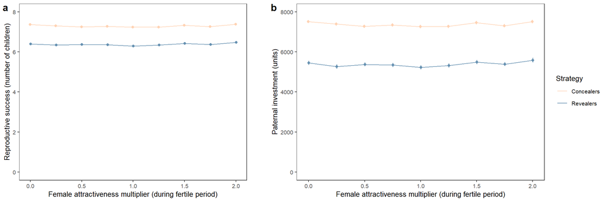

The attractiveness multiplier seems to have no effect on reproductive success or paternal investment, and does not interact with the main effect of strategy.

# 5. Competitor and mate search radiuses

Finally, we manipulate the radiuses that the female and male agents search in: both when searching for rivals to aggress against (females), and when searching for mates (males).

```r
d <-
  read.csv('data/v6/cleanData/ovulationSensitivity_Search.csv') %>%
  as_tibble() %>%
  mutate(Run               = factor(Run),
         competitor_radius = factor(competitor_radius),
         search_radius     = factor(search_radius),
         Strategy          = factor(Strategy))
```

## 5.1. Analyses

We run our final batch of ANOVAs, looking at the main effects of, and interactions between, (a) competitor radius, (b) mate search radius, and (c) female strategy. We’ll start with reproductive success as the DV.

```r
m5.1 <- aov(RS ~ search_radius*competitor_radius*Strategy + Error(Run/Strategy), data = d)

summary(m5.1)
```

```
##
## Error: Run
##                                   Df Sum Sq Mean Sq F value Pr(>F)
## search_radius                      3   97.6   32.52  45.813 <2e-16 ***
## competitor_radius                  3    5.5    1.84   2.594 0.0511 .
## search_radius:competitor_radius    9   13.7    1.53   2.151 0.0229 *
## Residuals                       1584 1124.5    0.71
## ---
## Signif. codes:  0 '***' 0.001 '**' 0.01 '*' 0.05 '.' 0.1 ' ' 1
##
## Error: Run:Strategy
##                                            Df Sum Sq Mean Sq  F value Pr(>F)
## Strategy                                    1  514.8   514.8 9498.200 <2e-16
## search_radius:Strategy                      3    5.1     1.7   31.425 <2e-16
## competitor_radius:Strategy                  3    0.3     0.1    1.557  0.198
## search_radius:competitor_radius:Strategy    9    0.2     0.0    0.407  0.932
## Residuals                                1584   85.8     0.1
##
## Strategy                                 ***
## search_radius:Strategy                   ***
## competitor_radius:Strategy
## search_radius:competitor_radius:Strategy
## Residuals
## ---
## Signif. codes:  0 '***' 0.001 '**' 0.01 '*' 0.05 '.' 0.1 ' ' 1
```

Not much going on, although male mate search radius slightly interacts with the effect of condition. We’ll probably find the same thing when we include paternal investment as the DV.

```r
m5.2 <- aov(PI ~ search_radius*competitor_radius*Strategy + Error(Run/Strategy), data = d)

summary(m5.2)
```

```
##
## Error: Run
##                                   Df    Sum Sq  Mean Sq F value  Pr(>F)
## search_radius                      3 9.575e+07 31917003  16.024 2.9e-10 ***
## competitor_radius                  3 1.638e+07  5460220   2.741  0.0420 *
## search_radius:competitor_radius    9 4.192e+07  4657928   2.338  0.0129 *
## Residuals                       1584 3.155e+09  1991886
## ---
## Signif. codes:  0 '***' 0.001 '**' 0.01 '*' 0.05 '.' 0.1 ' ' 1
##
## Error: Run:Strategy
##                                            Df    Sum Sq   Mean Sq  F value
## Strategy                                    1 2.592e+09 2.592e+09 7377.915
## search_radius:Strategy                      3 1.585e+07 5.284e+06   15.042
## competitor_radius:Strategy                  3 1.081e+06 3.605e+05    1.026
## search_radius:competitor_radius:Strategy    9 1.565e+06 1.739e+05    0.495
## Residuals                                1584 5.564e+08 3.513e+05
##                                            Pr(>F)
## Strategy                                  < 2e-16 ***
## search_radius:Strategy                   1.18e-09 ***
## competitor_radius:Strategy                  0.380
## search_radius:competitor_radius:Strategy    0.879
## Residuals
## ---
## Signif. codes:  0 '***' 0.001 '**' 0.01 '*' 0.05 '.' 0.1 ' ' 1
```

Even less going on. It seems that the search radiuses of agents do not substantially affect the trajectory of the model.

## 5.2. Visualisation

Let’s visualise this lack of effect directly, for both DVs.

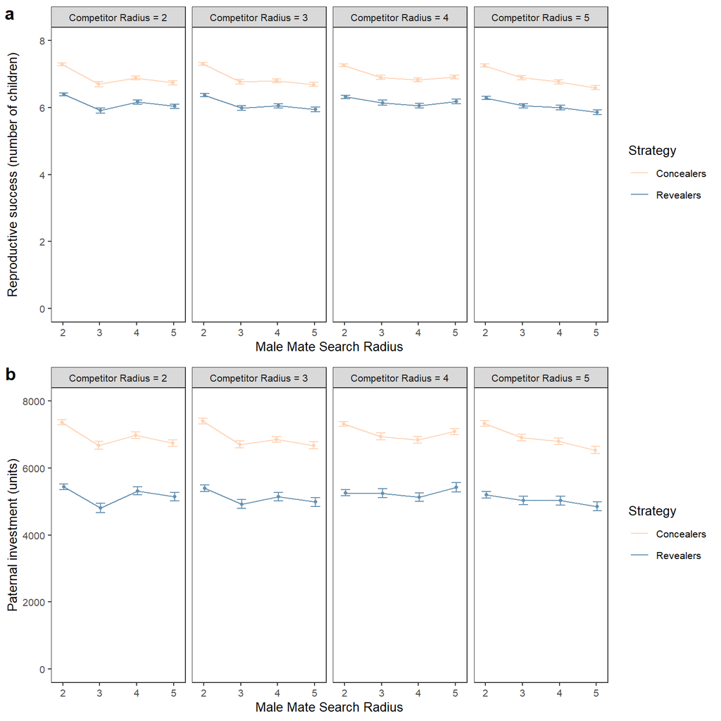